# Дослідження за допомогою візуалізації

# Головна ідея використання візуалізації для аналізу даних:

Завжди показуйте стільки даних, скільки зможете - summary недостатньо! (якщо даних занадто багато, використовуйте випадкову вибірку)

Приклад: всі набори даних, які ви зараз побачите, мають однакові підсумкові дані: однакові середні, стандартні відхилення, і навіть коефіцієнт кореляції

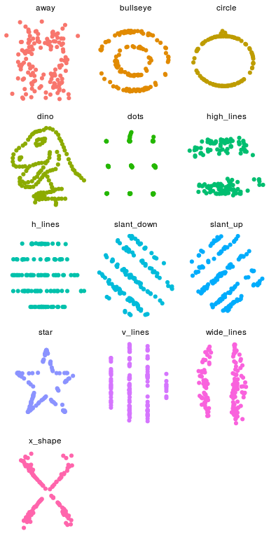

(Візуальний) аналіз даних - це непростий, інтерактивний процес, який до того ж вимагає фантазії. Все починається із запитань, які ви ставите для себе, і відповідь на які повинна бути в даних. Далі можуть виникнути наступні запитання, потім ще наступні - в цьтому і є інтерактивність.

Що ви отримуєте за допомогою такого аналізу?

- Розуміння як влаштовані ваші дані
- Можна побачити якісні властивості даних, а не лише велику таблицю з числами
- Якщо пощастить, знайти нові патерни, або асоціації

Не пощастило:

[figure not shown]

### Мистецтво ставити питання

Які запитання найчастіше найбільш корисні для такого аналізу?

| Питання | Візуальний аналіз |
| --- | --- |
| Як саме змінюється ваша змінна | Розподіл, тренд (для даних з часом) |
| Які точки виходять за межі (outliers) | Краї розподілу |
| Як пов“язані ваші змінні? | графік розсіяння, матриця розсіяння |
| Чи можемо ми спростувати / підтвердити гіпотезу … | … в залежності від гіпотези, але найчастіше - графік розсіяння у якісь формі |

Ок, я згоден що перехід між тертьою та четвертою строками схожий на цю картинку:

[figure not shown]

але нічого кращого запропонувати не можу - навчитися задавати правильні питання та перевіряти візуалізацією можна лише після деякої практики

### Практика

#### Дані

```r
library(readr)
protocols_unnested <- read_csv("~/code/presentation_tapas/data/protocols.unnested.csv",
  col_types = cols(date = col_skip(), docs = col_skip(),
  file = col_skip(), firm = col_skip(),
  notes = col_skip(), price = col_skip()))
```

[output not shown]

```r
# filter
df <- protocols_unnested %>%
  filter(price.extr < 10^8) %>%
  filter(purchase_cost_uah > 0 ) %>%
  filter(!is.na(purchase_cost_uah) )
```

### Список питань

1. Скільки разів учасники перемагали(катег. змінна)
2. З яких регіонів переможці?
3. Якою була ціна угод?
4. Скільки претендентів брали участь у торгах?
5. Залежність ціни від кількості учасників?

#### Питання №1: cкільки разів учасники перемагали

Переможці

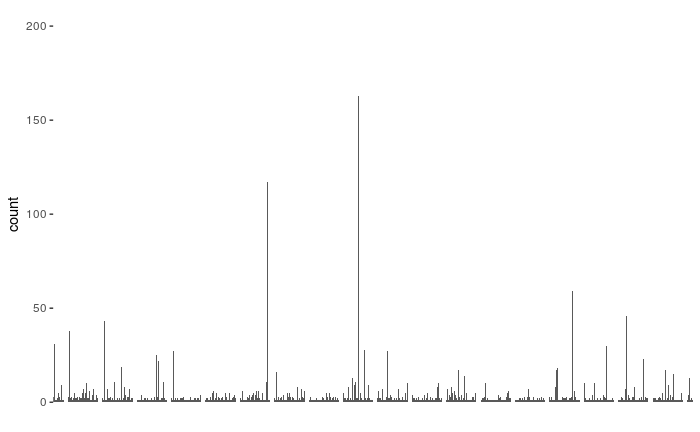

```r
# df %>%
#   filter(!is.na(code))  %>%
#   filter(winner) %>%
#   ggplot(aes(x = code)) + geom_histogram(stat="count") + nuke_xlabels + ylim(0, 200)
df %>%
  filter(!is.na(code))  %>%
  filter(winner) %>%
  ggplot() +
  geom_bar(mapping = aes(x = code)) +  nuke_xlabels + ylim(0, 200)
```

### Питання 2 - регіони - переможці

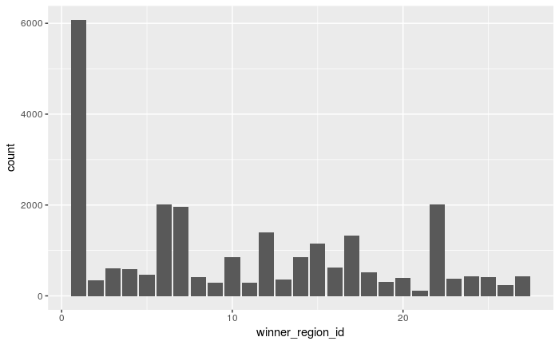

```r
df %>%
  filter(!is.na(winner_region_id))  %>%
  filter(winner == "TRUE" ) %>%
  ggplot() +
  geom_bar(mapping = aes(x = winner_region_id))
```

#### Питання №3: якою була ціна угод?

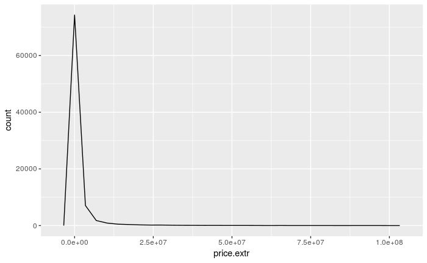

```r
df %>%
  ggplot() +
  geom_freqpoly(aes(x = price.extr))
```

#### Питання №4 Скільки претендентів брали участь у торгах?

```r
df %>%
  group_by(contract_id) %>%
  summarise(participants = n()) %>%
  arrange(desc(participants))
```

| contract_id | participants |
| --- | --- |
| 482082 | 40 |
| 565400 | 36 |
| 574032 | 22 |
| 538264 | 20 |
| 538265 | 20 |
| 584905 | 19 |
| 524991 | 18 |
| 497348 | 17 |
| 429153 | 16 |
| 446366 | 16 |

[output cut: 990 more lines]

```r
NA
```

… Але графік - краще!

```
Ignoring unknown parameters: binwidth, bins, pad
```

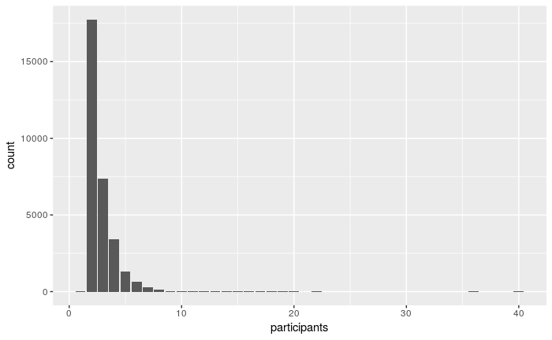

```r
df %>%
  group_by(contract_id) %>%
  summarise(participants = n()) %>%
  arrange(desc(participants)) %>%
  ggplot(aes(x = participants)) + geom_histogram(stat="count")
```

```r
NA
```

### Питання №5: Залежність ціни від кількості учасників

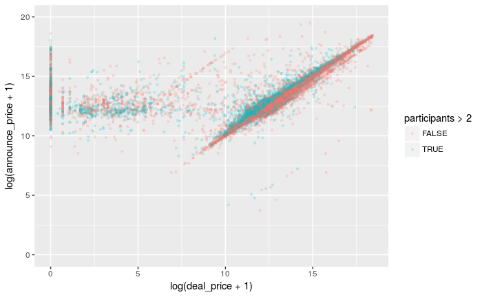

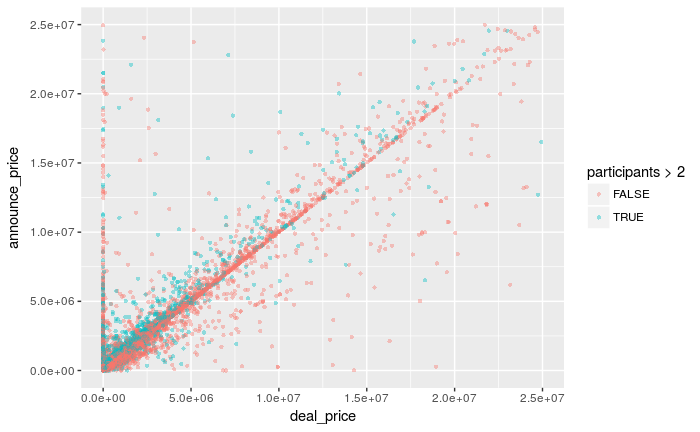

Отже, скаттерплоти та розподіли - це наше все … насамкінець, рпо те що є класний спосіб подивитися все на одній картинці: матриця скатерплотів

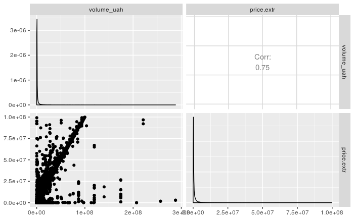

```r
library(GGally)
df %>%
  ggpairs( columns = c("volume_uah", "price.extr") )
```

Або на іншому датасеті:

[output not shown]

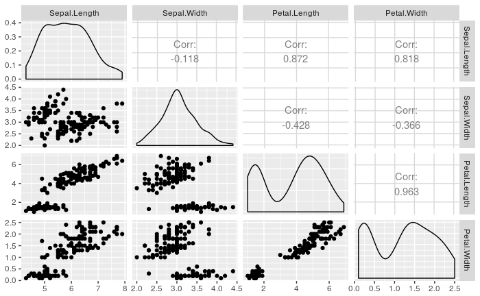